# Multiple Comparison Criteria

`compare()` and `plot_compare()`

Author

biomAid package

Published

October 5, 2026

[figure not shown]

## Overview

`compare()` computes a pairwise comparison criterion — **HSD**, **LSD**, or **Bonferroni-corrected LSD** — for predicted values obtained from an ASReml-R V4 model. The criterion is a single number: two predicted values in the same group are declared significantly different if and only if their absolute difference exceeds it.

Three comparison types are available:

| Type | Formula | Multiple-testing control | Best used when |
| --- | --- | --- | --- |
| `"HSD"` (Tukey) | $\frac{\overline{\text{SED}}}{\sqrt{2}} \times q_{1-\alpha}(n_g, \nu)$ | Family-wise (exact for balanced designs) | Routine variety/treatment comparisons |
| `"LSD"` | $\overline{\text{SED}} \times t_{\alpha/2,\,\nu}$ | None | Exploratory or preplanned single comparisons |
| `"Bonferroni"` | $\overline{\text{SED}} \times t_{\alpha/(2m),\,\nu}$ | Family-wise (conservative) | Small number of specific comparisons |

The companion function `plot_compare()` turns a `compare()` result directly into publication-ready visualisations: a sorted **dot plot** with a criterion-width band, a **compact letter display** (CLD), or a **pairwise significance heatmap**.

## Mathematical Framework

### Prediction error variance and the average SED

Let $\hat{\boldsymbol{\tau}}_g = (\hat{\tau}_{1g}, \ldots, \hat{\tau}_{n_g g})^\top$ be the vector of $n_g$ predicted values in group $g$, with prediction error variance–covariance matrix

$$\mathbf{V}_g = \operatorname{Var}(\hat{\boldsymbol{\tau}}_g - \boldsymbol{\tau}_g),$$

returned by `predict(model, classify = term, vcov = TRUE)$vcov` in ASReml-R V4.

The standard error of a difference (SED) for the pair $(i, j)$ is

$$\text{SED}_{ij} = \sqrt{V_{ii} + V_{jj} - 2V_{ij}}.$$

`compare()` uses the **arithmetic mean SED** across all $m = \binom{n_g}{2}$ pairs as the representative spread of prediction error:

$$\overline{\text{SED}}_g
= \frac{1}{m}\sum_{i < j} \text{SED}_{ij}.$$

Using the average SED (rather than a single representative pair) is robust when PEVs vary across units — as they do in unbalanced designs and spatial models.

### Comparison criteria

Let $\nu = \texttt{model\$nedf}$ be the error degrees of freedom.

**Tukey HSD** — controls the family-wise error rate (FWER) exactly for balanced designs by referring to the Studentised range distribution:

$$\text{HSD}_g
= \frac{\overline{\text{SED}}_g}{\sqrt{2}} \times
q_{1-\alpha}(n_g, \nu),$$

where $q_{1-\alpha}(n_g, \nu)$ is the upper $\alpha$ critical value of the Studentised range with $n_g$ means and $\nu$ degrees of freedom.

**LSD** — no multiplicity correction; equivalent to a two-sided $t$-test at level $\alpha$ for each pair:

$$\text{LSD}_g = \overline{\text{SED}}_g \times t_{\alpha/2,\,\nu}.$$

**Bonferroni** — applies the Bonferroni correction across all $m$ pairs, controlling the FWER conservatively:

$$\text{Bonferroni}_g
= \overline{\text{SED}}_g \times t_{\alpha / (2m),\,\nu}.$$

For all three types: $|\hat{\tau}_i - \hat{\tau}_j| > \text{criterion}$ declares pair $(i, j)$ significantly different.

### Posterior variance (`pev = FALSE`)

When `term` is in the **random** part of the model, the PEV $\mathbf{V}_{\hat{\boldsymbol{\tau}}}$ underestimates the uncertainty of the difference between BLUPs. Setting `pev = FALSE` substitutes the **posterior variance**

$$\operatorname{Var}(\hat{\boldsymbol{\tau}} \mid \mathbf{y})
= \mathbf{G} - \mathbf{V}_{\hat{\boldsymbol{\tau}}}$$

which accounts for the shrinkage in BLUP estimation and gives a more appropriate measure of uncertainty for genotypic BLUPs.

## Setup

### Simulated data and model

> **Requires:** ASReml-R V4. The vignette is pre-rendered so no licence is needed to read it; run the code chunks only if you have ASReml-R installed.

We use `simTrialData()` to generate a balanced multi-environment trial with 20 varieties, 4 sites, and 3 nitrogen treatments (T0, T1, T2).

```r
out <- simTrialData(
  nvar        = 20L,
  nsite       = 4L,
  treatments  = c("T0", "T1", "T2"),
  nrep        = 3L,
  seed        = 42L,
  verbose     = FALSE,
  sim.options = list(treat_effects = c(0, 80, 200))
)
dat        <- out$data
dat$Row    <- factor(dat$Row)
dat$Column <- factor(dat$Column)
```

We fit a **fixed `Treatment × Site × Variety` model** with site-within-replicate random effects and a spatial residual structure. Variety must be in the fixed effects so that `predict()` returns BLUEs for every Variety × Site combination — the basis for the comparison criteria.

```r
asreml.options(trace = FALSE)
model <- asreml(
  yield    ~ Treatment * Site * Variety,
  random   = ~ at(Site):Rep,
  residual = ~ dsum(~ ar1(Row):ar1(Column) | Site),
  data     = dat,
  maxit    = 30L
)
model <- update(model)
```

## Example 1: HSD — single global group

The simplest use: compare all variety BLUEs across the trial in a single global group (no `by` argument). `compare()` calls `predict()` internally using `term` as the `classify`.

```r
res1 <- compare(
  model,
  term = "Variety",
  type = "HSD"
)

head(res1[order(res1$predicted.value, decreasing = TRUE), ])
```

```
   Variety predicted.value std.error     HSD    avsed
3    Var03        4589.054  75.90729 291.038 81.66208
1    Var01        4486.818  75.78770 291.038 81.66208
16   Var16        4451.167  75.89394 291.038 81.66208
19   Var19        4436.358  75.91554 291.038 81.66208
11   Var11        4380.288  75.99388 291.038 81.66208
17   Var17        4374.427  75.76652 291.038 81.66208
```

The `HSD` column is **constant within the group** — all predicted values share the same criterion. Two varieties are significantly different if `|pred_i - pred_j| > HSD`. The `avsed` column records the average SED on which the criterion is based.

Applying the criterion manually:

```r
# Are Var01 and Var20 significantly different?
preds <- setNames(res1$predicted.value, as.character(res1$Variety))
diff  <- abs(preds["Var01"] - preds["Var20"])
cat("|Var01 - Var20| =", round(diff, 1L),
    "  HSD =",           round(res1$HSD[1L], 1L),
    "  Significant:",    diff > res1$HSD[1L], "\n")
```

```
|Var01 - Var20| = 478   HSD = 291   Significant: TRUE
```

## Example 2: HSD by site

Adding `by = "Site"` performs independent comparisons within each site, using each site’s own prediction error variance matrix and thus its own criterion. This is the most common usage: **20 varieties compared within each of 4 sites**.

```r
res_hsd <- compare(
  model,
  term = "Variety:Site",
  by   = "Site",
  type = "HSD"
)

# HSD varies by site (different PEV per site from the spatial model)
unique(res_hsd[, c("Site", "HSD", "avsed")])
```

```
  Site      HSD    avsed
1 Env1 582.4568 163.4310
2 Env2 583.6384 163.7625
3 Env3 555.5791 155.8894
4 Env4 605.4231 169.8751
```

The HSD differs between sites because the spatial AR1×AR1 residual structure gives each site its own effective error variance. Sites with tighter spatial control (lower `avsed`) have a smaller, more powerful criterion.

## Example 3: Multi-factor `by`

When predictions span multiple factors, `by` accepts a character vector. Here varieties are compared **within every Site × Treatment combination** — asking “which varieties perform best under each treatment at each site?”. The colon-string form `"Site:Treatment"` is equivalent to the vector form.

```r
# Compare varieties within each Site × Treatment combination
res3a <- compare(model, term = "Variety:Site:Treatment",
                 by = c("Site", "Treatment"), type = "HSD")
res3b <- compare(model, term = "Variety:Site:Treatment",
                 by = "Site:Treatment", type = "HSD")

# HSD per Site × Treatment group (first 6 of 12 groups)
unique(res3a[, c("Site", "Treatment", "HSD", "avsed")])[1:6, ]
```

```
  Site Treatment      HSD    avsed
1 Env1        T0 1010.630 283.5717
2 Env1        T1 1010.399 283.5069
3 Env1        T2 1009.974 283.3875
4 Env2        T0 1013.048 284.2503
5 Env2        T1 1012.681 284.1472
6 Env2        T2 1011.444 283.8001
```

The criterion varies across Site × Treatment combinations because each sub-environment has its own spatial error structure.

## Example 4: LSD and Bonferroni

The three criteria differ only in the multiplier applied to `avsed`. LSD is the most liberal (no correction); Bonferroni is the most conservative; HSD sits between them for most group sizes.

```r
res_lsd <- compare(model, term = "Variety:Site", by = "Site", type = "LSD")
res_bon <- compare(model, term = "Variety:Site", by = "Site",
                   type = "Bonferroni")

# Criteria for Env1 (res_hsd already computed in Example 2)
env1 <- function(r, col) round(unique(r[[col]][r$Site == "Env1"]), 1L)
cat("Env1 criteria (20 varieties):\n")
```

```
Env1 criteria (20 varieties):
```

```r
cat("  LSD        =", env1(res_lsd, "LSD"),        "\n")
```

```
  LSD        = 321.1
```

```r
cat("  HSD        =", env1(res_hsd, "HSD"),        "\n")
```

```
  HSD        = 582.5
```

```r
cat("  Bonferroni =", env1(res_bon, "Bonferroni"), "\n")
```

```
  Bonferroni = 600.9
```

For 20 varieties, $m = \binom{20}{2} = 190$ pairs. The Bonferroni correction is very conservative at this scale — HSD is generally preferred for large variety trials.

## Example 5: Variety BLUPs with `pev = FALSE`

When variety is in the **random** effects the PEV understates uncertainty because it ignores the shrinkage towards zero inherent in BLUP estimation. Setting `pev = FALSE` substitutes the posterior variance $\mathbf{G} - \mathbf{PEV}$, giving a more appropriate — and larger — criterion.

We refit the model with **Variety in the random effects** and `Treatment × Site` fixed, so `predict()` returns BLUPs rather than BLUEs.

```r
model_rnd <- asreml(
  yield    ~ Treatment * Site,
  random   = ~ Variety + at(Site):Rep,
  residual = ~ dsum(~ ar1(Row):ar1(Column) | Site),
  data     = dat,
  maxit    = 30L
)
model_rnd <- update(model_rnd)
```

```r
res_pev  <- compare(model_rnd, term = "Variety", type = "HSD", pev = TRUE)
res_post <- compare(model_rnd, term = "Variety", type = "HSD", pev = FALSE)

cat("HSD (PEV):                    ", round(res_pev$HSD[1L],  1L), "\n")
```

```
HSD (PEV):                     296.5
```

```r
cat("HSD (posterior variance):     ", round(res_post$HSD[1L], 1L), "\n")
```

```
HSD (posterior variance):      969.3
```

```r
cat("Ratio (posterior / PEV HSD):  ",
    round(res_post$HSD[1L] / res_pev$HSD[1L], 2L), "\n")
```

```
Ratio (posterior / PEV HSD):   3.27
```

The posterior-variance HSD is larger than the PEV-based HSD, reflecting the additional uncertainty that BLUP shrinkage introduces. Using `pev = TRUE` on a random-effects term underestimates the true uncertainty of a difference between BLUPs and will declare too many pairs significant.

> **Note:** `pev = FALSE` is only meaningful when `term` is in the **random** part of the model. When the term is fixed (as in Examples 1–4 above), `pev = TRUE` (the default) is always correct.

## Example 6: Adjusting `alpha`

A stricter significance level widens the criterion, reducing the number of significant pairs.

```r
r_05 <- compare(model, term = "Variety:Site", by = "Site",
                type = "HSD", alpha = 0.05)
r_01 <- compare(model, term = "Variety:Site", by = "Site",
                type = "HSD", alpha = 0.01)

env1_05 <- unique(r_05$HSD[r_05$Site == "Env1"])
env1_01 <- unique(r_01$HSD[r_01$Site == "Env1"])
cat("Env1  alpha=0.05 HSD:", round(env1_05, 1L), "\n")
```

```
Env1  alpha=0.05 HSD: 582.5
```

```r
cat("Env1  alpha=0.01 HSD:", round(env1_01, 1L), "\n")
```

```
Env1  alpha=0.01 HSD: 657.6
```

## Visualisation with `plot_compare()`

`plot_compare()` reads the `compare()` result directly and infers the grouping structure automatically — no extra arguments are needed to handle `by` groups.

### Dot plot — `type = "dotplot"`

Varieties are sorted by predicted value, highest at the top. A **shaded band** of width equal to the HSD is drawn below the top-ranked variety. Any variety within the band is not significantly different from the best; those outside (coloured red) are. The dashed vertical line marks the top-ranked predicted value.

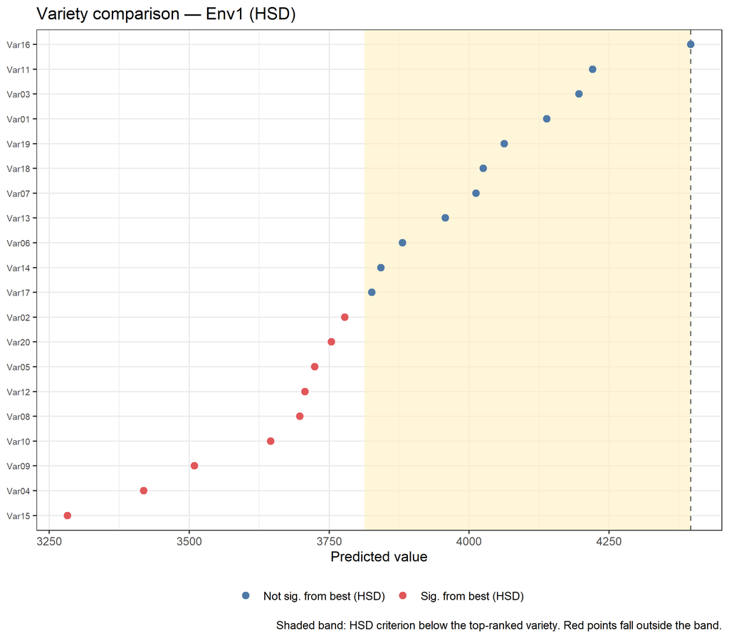

```r
p1 <- plot_compare(res_hsd |> subset(Site == "Env1"), type = "dotplot") +
  ggtitle("Variety comparison — Env1 (HSD)")
print(p1)
```

When a `by`-grouped result is passed, each group becomes its own facet panel with its own site-specific criterion band:

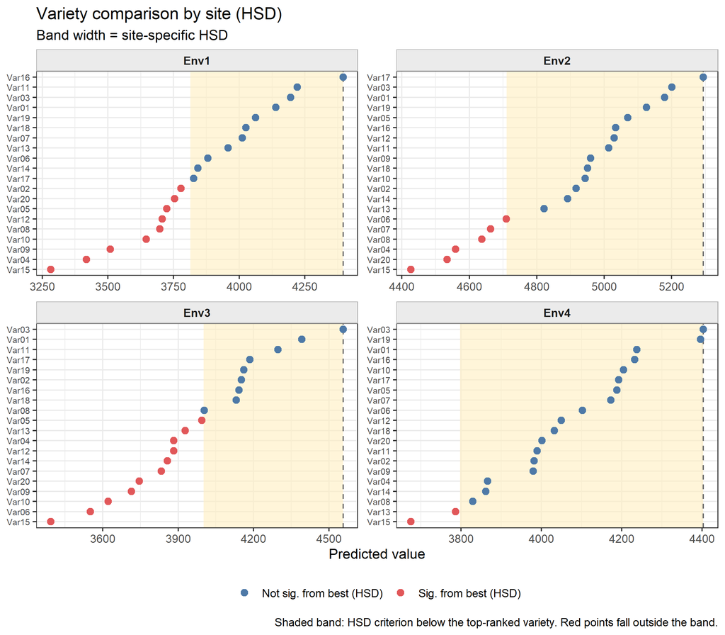

```r
p2 <- plot_compare(res_hsd, type = "dotplot") +
  ggtitle("Variety comparison by site (HSD)",
          subtitle = "Band width = site-specific HSD")
print(p2)
```

### Reference variety — `reference =`

Setting `reference` centres the band on a named variety rather than the best. Points are coloured three ways: **green** (significantly better), **blue** (not significantly different), **red** (significantly worse). The reference variety is shown as a filled diamond.

This is the natural way to ask *“which varieties are significantly better or worse than our commercial check?”*

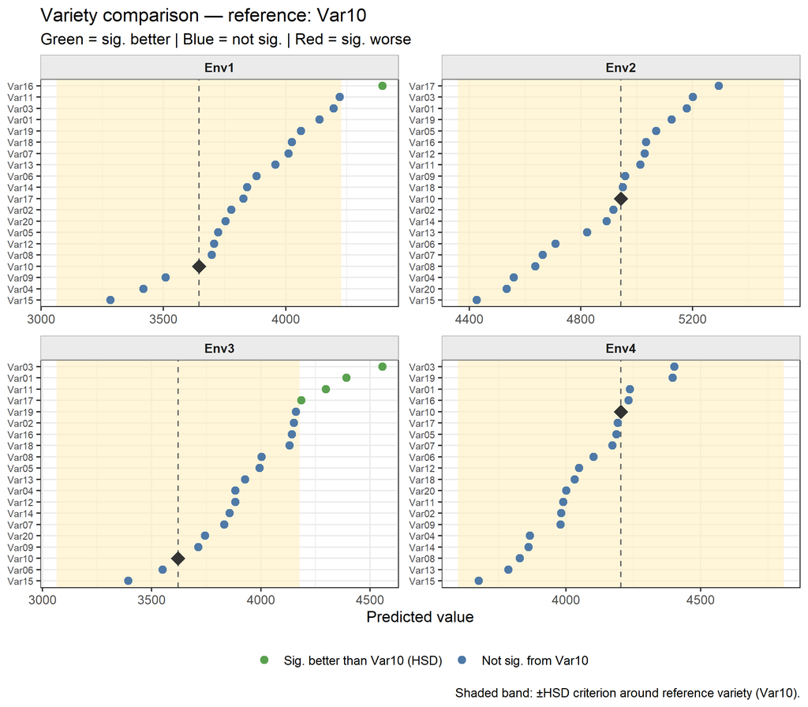

```r
# Use Var10 as the commercial check reference
p3 <- plot_compare(res_hsd, type = "dotplot", reference = "Var10") +
  ggtitle("Variety comparison — reference: Var10",
          subtitle = "Green = sig. better | Blue = not sig. | Red = sig. worse")
print(p3)
```

### Half-criterion error bars — `type = "errbar"`

Each variety is shown as a point (its predicted value) with a horizontal line segment spanning $\hat{\tau} \pm \frac{1}{2}\text{HSD}$. The visual significance rule is exact: **two varieties are significantly different if and only if their bars do not overlap**. This is equivalent to the criterion test $|\hat{\tau}_i - \hat{\tau}_j| > \text{HSD}$.

The error bar display is particularly useful when interest lies in all pairwise comparisons rather than just comparisons with the best variety — every non-overlapping pair stands out directly, not just those that fall outside a single band.

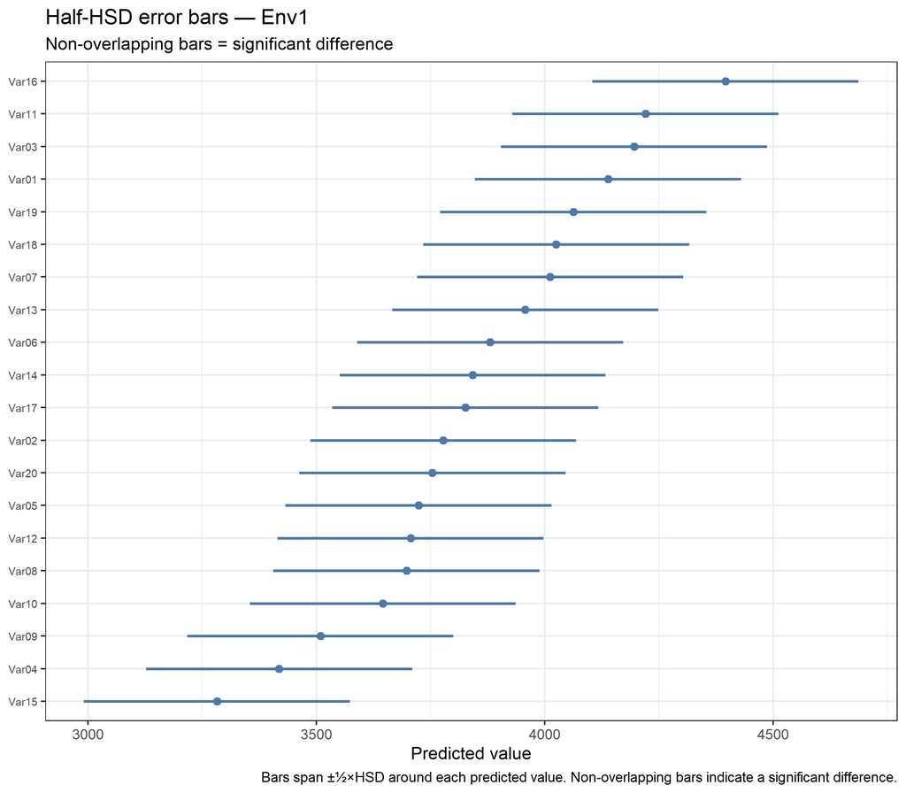

```r
p_eb1 <- plot_compare(res_hsd |> subset(Site == "Env1"), type = "errbar") +
  ggtitle("Half-HSD error bars — Env1",
          subtitle = "Non-overlapping bars = significant difference")
print(p_eb1)
```

With a `by`-grouped result, each site gets its own panel. Bar widths differ between sites because each site has its own spatial error variance and therefore its own HSD.

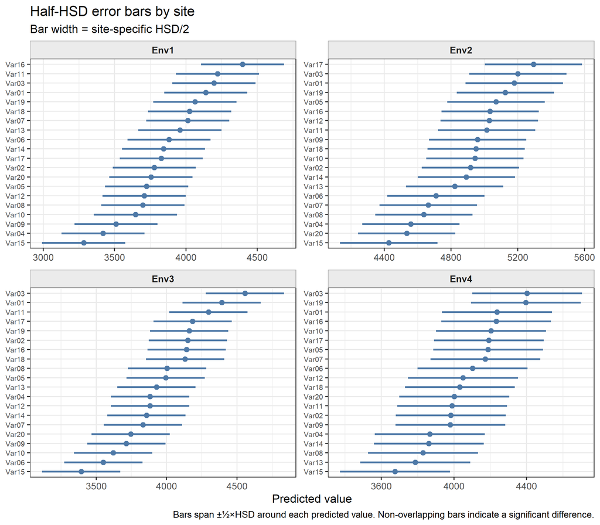

```r
p_eb2 <- plot_compare(res_hsd, type = "errbar") +
  ggtitle("Half-HSD error bars by site",
          subtitle = "Bar width = site-specific HSD/2")
print(p_eb2)
```

The criterion type changes the bar width directly — LSD bars are shorter (more discriminating) and Bonferroni bars are wider (more conservative). This makes the effect of the multiplicity correction immediately visible:

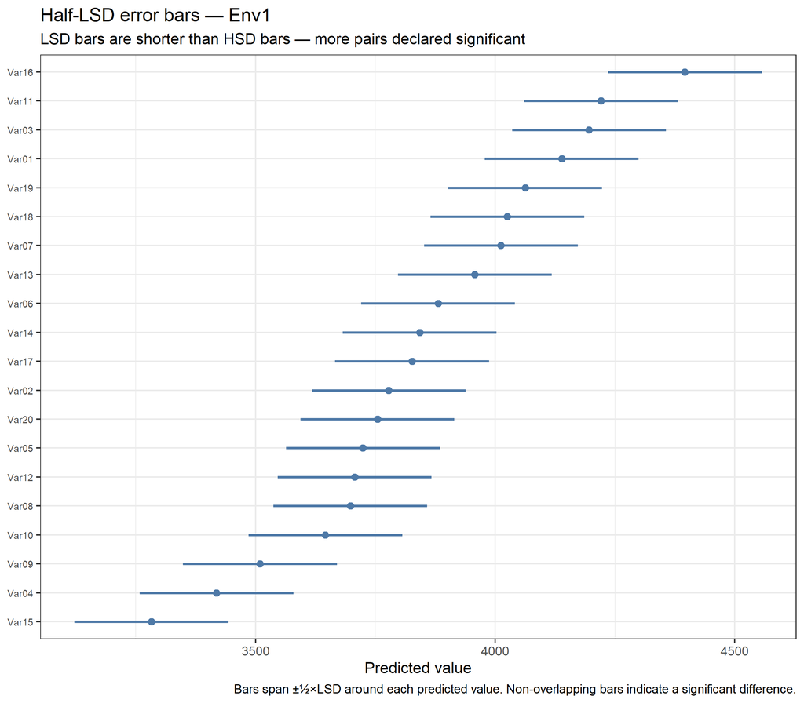

```r
p_eb3 <- plot_compare(res_lsd |> subset(Site == "Env1"), type = "errbar") +
  ggtitle("Half-LSD error bars — Env1",
          subtitle = "LSD bars are shorter than HSD bars — more pairs declared significant")
print(p_eb3)
```

### Compact letter display — `type = "letters"`

The compact letter display (CLD) is the standard reporting format in plant science. Varieties sharing at least one letter are not significantly different. Letters are assigned by the descending sweep algorithm using the HSD as the significance threshold.

[figure not shown]

```r
p4 <- plot_compare(res_hsd |> subset(Site == "Env1"), type = "letters") +
  ggtitle("Compact letter display — Env1 (HSD)")
print(p4)
```

With `by`-groups, each site gets its own panel with independent letter assignments:

[figure not shown]

```r
p5 <- plot_compare(res_hsd, type = "letters") +
  ggtitle("CLD — 20 varieties by site",
          subtitle = "Letters are independent within each site")
print(p5)
```

### Pairwise significance heatmap — `type = "heatmap"`

The heatmap shows all $\binom{20}{2} = 190$ pairwise absolute differences as a colour-coded matrix. A white cross (×) marks pairs that exceed the HSD criterion. For 20+ varieties this reveals the full discrimination pattern at a glance — something no letter display can convey.

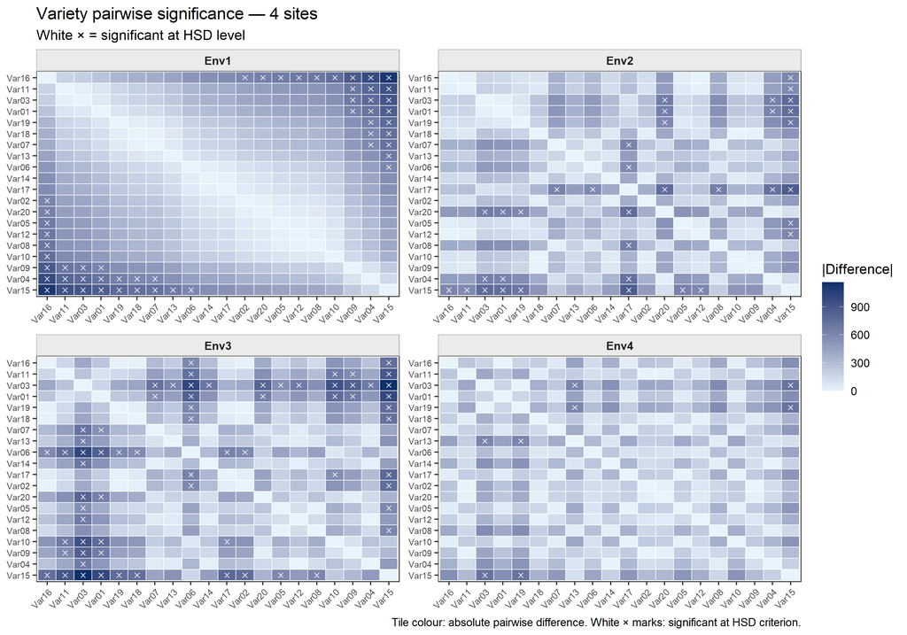

```r
p6 <- plot_compare(res_hsd, type = "heatmap") +
  ggtitle("Variety pairwise significance — 4 sites",
          subtitle = "White × = significant at HSD level")
print(p6)
```

### Interactive dotplot — `interactive = TRUE`

Setting `interactive = TRUE` returns a `pc_interactive` object which, when printed or passed through `as_plotly()`, renders an interactive **plotly** widget. The dotplot gains a hover interaction: hovering over any variety **moves the criterion band** to be centred on that variety’s predicted value and **recolours all points** relative to it (green = significantly better, blue = not significant, red = significantly worse). Unhovering restores the original state. You can still use `+` to add ggplot2 layers before the conversion.

The widget is not embedded in this vignette — it adds roughly 13 MB to the page — so run the following yourself to see it:

```r
# Single-site subset keeps the demo focused on the hover interaction
as_plotly(plot_compare(res_hsd |> subset(Site == "Env1"),
                       type = "dotplot", interactive = TRUE))
```

> **Note:** `interactive = TRUE` requires the **plotly** package (`install.packages("plotly")`). In RStudio the widget appears in the Viewer pane, not the Graphics pane.

> **Multi-panel use:** pass the full `by`-grouped result to get one facet per group. `as_plotly()` automatically adjusts subplot spacing; set `height` (pixels) if you need more room, e.g. `as_plotly(plot_compare(res_hsd, ...), height = 700)`.

### Extracting plot data — `return_data = TRUE`

```r
df_dot <- plot_compare(res_hsd, type = "dotplot", return_data = TRUE)
head(df_dot[, c("Group", "Variety", "pred", "crit", "rank", "sig")])
```

```
   Group Variety     pred     crit rank sig
61  Env1   Var16 4395.824 582.4568    1  ns
41  Env1   Var11 4220.600 582.4568    2  ns
9   Env1   Var03 4195.903 582.4568    3  ns
1   Env1   Var01 4138.850 582.4568    4  ns
73  Env1   Var19 4062.687 582.4568    5  ns
69  Env1   Var18 4025.355 582.4568    6  ns
```

```r
df_heat <- plot_compare(res_hsd |> subset(Site == "Env1"),
                        type   = "heatmap",
                        return_data = TRUE)
head(df_heat[, c("Var_x", "Var_y", "diff", "sig")])
```

```
  Var_x Var_y     diff   sig
1 Var16 Var16   0.0000 FALSE
2 Var11 Var16 175.2239 FALSE
3 Var03 Var16 199.9211 FALSE
4 Var01 Var16 256.9737 FALSE
5 Var19 Var16 333.1371 FALSE
6 Var18 Var16 370.4685 FALSE
```

The ggplot object returned by `plot_compare()` can also be extended with `+`:

[figure not shown]

```r
plot_compare(res_hsd, type = "letters") +
  ggplot2::ggtitle("Tukey HSD — 20 varieties across 4 sites",
                   subtitle = "alpha = 0.05 | Letters independent per site") +
  ggplot2::xlab("Predicted yield (kg/ha)")
```

## Summary

### `compare()`

| Task | Specification |
| --- | --- |
| HSD (Tukey) criterion | `type = "HSD"` (default) |
| LSD (unadjusted) criterion | `type = "LSD"` |
| Bonferroni criterion | `type = "Bonferroni"` |
| One global group | `by = NULL` (default) |
| Single factor by-group | `by = "Site"` |
| Multi-factor by-group | `by = c("Site", "Treatment")` or `by = "Site:Treatment"` |
| Stricter significance level | `alpha = 0.01` |
| Use posterior variance for BLUPs | `pev = FALSE` |
| Pass extra args to `predict()` | `...` (e.g. `present = ...`) |

### `plot_compare()`

| Task | Specification |
| --- | --- |
| Sorted dot plot with criterion band | `type = "dotplot"` (default) |
| Half-criterion error bars (non-overlap = significant) | `type = "errbar"` |
| Compact letter display | `type = "letters"` |
| Pairwise significance heatmap | `type = "heatmap"` |
| Band anchored to best variety | `reference = NULL` (default) |
| Band anchored to specific variety | `reference = "VarName"` |
| Interactive plotly widget | `interactive = TRUE` |
| Extend before plotly conversion | `result + ggtitle(...)` |
| Export tidy data frame | `return_data = TRUE` |

## References

Tukey, J.W. (1949). Comparing individual means in the analysis of variance. *Biometrics*, **5**(2), 99–114.

Piepho, H.P. (2004). An algorithm for a letter-based representation of all pairwise comparisons. *Journal of Computational and Graphical Statistics*, **13**(2), 456–466.